# Individual Portion: Streaming Data

STT2860 F22 Project 03

Graham Dotson

Tuesday, December 13, 2022 @ 11:52 AM

## Setup

### Packages Used

```r
library(tidyverse)
```

### Background of the Data

The datasets were downloaded from [Disney+ Movies and TV Shows | Kaggle](https://www.kaggle.com/datasets/shivamb/disney-movies-and-tv-shows) and [TV shows on Netflix, Prime Video, Hulu and Disney+ | Kaggle](https://www.kaggle.com/datasets/ruchi798/tv-shows-on-netflix-prime-video-hulu-and-disney). You can read about them there, including variable definitions, sources, when they were created, and other information. Load the two datasets and use `glimpse()` to explore their structures.

#### Disney+ Dataset

```r
Disney <- read_rds("data/disneypluscontent.rds")
glimpse(Disney)
```

```
Rows: 1,446
Columns: 13
$ show_id       <chr> "s1", "s2", "s3", "s4", "s6", "s7", "s8", "s9", "s10", "…
$ type          <chr> "Movie", "Movie", "Movie", "Movie", "Movie", "TV Show", …
$ title         <chr> "Duck the Halls: A Mickey Mouse Christmas Special", "Ern…
$ director      <chr> "Alonso Ramirez Ramos, Dave Wasson", "John Cherry", "Kar…
$ cast          <chr> "Chris Diamantopoulos, Tony Anselmo, Tress MacNeille, Bi…
$ country       <chr> NA, NA, "United States", NA, "United States", NA, "Unite…
$ date_added    <chr> "26-Nov-21", "26-Nov-21", "26-Nov-21", "26-Nov-21", "24-…
$ release_year  <dbl> 2016, 1988, 2011, 2021, 2021, 2021, 2015, 2019, 2008, 20…
$ rating        <fct> TV-G, PG, TV-G, TV-PG, PG-13, TV-14, TV-14, TV-PG, G, TV…
$ duration      <chr> "23", "91", "23", "41", "94", "1", "2", "2", "45", "59",…
$ duration_unit <chr> "min", "min", "min", "min", "min", "Seasons", "Seasons",…
$ listed_in     <chr> "Animation, Family", "Comedy", "Animation, Comedy, Famil…
$ description   <chr> "Join Mickey and the gang as they duck the halls!", "San…
```

#### Streaming Dataset

```r
Streamingcontent <- read_rds("data/streamingcontent.rds")
glimpse(Streamingcontent)
```

```
Rows: 21,472
Columns: 8
$ ID             <dbl> 1, 1, 1, 1, 2, 2, 2, 2, 3, 3, 3, 3, 4, 4, 4, 4, 5, 5, 5…
$ Title          <chr> "Breaking Bad", "Breaking Bad", "Breaking Bad", "Breaki…
$ Year           <dbl> 2008, 2008, 2008, 2008, 2016, 2016, 2016, 2016, 2013, 2…
$ Age            <fct> 18+, 18+, 18+, 18+, 16+, 16+, 16+, 16+, 18+, 18+, 18+, …
$ IMDb           <chr> "9.4/10", "9.4/10", "9.4/10", "9.4/10", "8.7/10", "8.7/…
$ RottenTomatoes <chr> "100/100", "100/100", "100/100", "100/100", "96/100", "…
$ Service        <chr> "Netflix", "Hulu", "Prime Video", "Disney+", "Netflix",…
$ YesNo          <dbl> 1, 0, 0, 0, 1, 0, 0, 0, 1, 1, 0, 0, 1, 0, 0, 0, 1, 0, 0…
```

## Analyses

### Create the Analysis Datasets

#### Disney+ Dataset

Use `select()` to delete the variables `director`, `cast`, `country`, `listed in`, and `description` from the dataset.

```r
library(ggplot2)
Disney <- select(Disney, -c(director, cast, country, listed_in, description))
```

#### Streaming Dataset

I used a function called `pivot_longer()` on the downloaded data to change the shape of the dataset. You will need to do additional necessary editing on the dataset before you analyze it.

- Use `filter()` to remove any row where `YesNo` is `0` (a `0` means it is *not* on the service).
- Use the `separate()` function to split `IMDb`. Separate the show rating from the max rating of `10`.
- Use the `separate()` function to split `RottenTomatoes`. Separate the show rating from the max rating of `100`.
- Use `mutate()` to convert the shows’ IMDb and Rotten Tomatoes ratings into numerical variables instead of categorical.

```r
Streamingcontent <- filter(Streamingcontent, YesNo != 0)
Streamingcontent <- separate(Streamingcontent, IMDb, c("IMDb_rating", "IMDb_max"), "/")
Streamingcontent <- separate(Streamingcontent, RottenTomatoes, c("RottenTomatoes_rating", "RottenTomatoes_max"), "/")
Streamingcontent <- mutate(Streamingcontent, IMDb_rating = as.numeric(IMDb_rating), RottenTomatoes_rating = as.numeric(RottenTomatoes_rating))
```

### Visualization 1: Release Year

**These plots use the Disney+ Dataset.**

A frequency polygon (`geom_freqpoly()`) is an alternative to a histogram. Rather than displaying bars, it connects the midpoints of a histogram’s bars with line segments. Create a frequency polygon for the year in which Disney+ content was released. Add an appropriate title and axis labels. Use other formatting as you choose to enhance effectiveness/appearance.

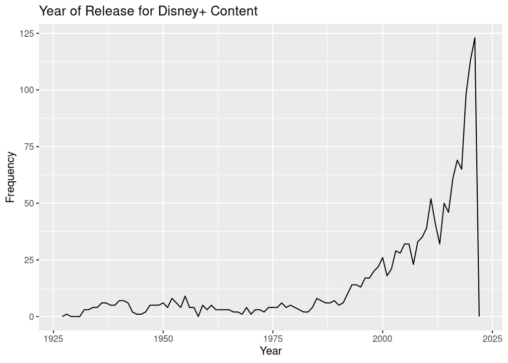

```r
library(ggplot2)
ggplot(Disney, aes(x = release_year)) +
  geom_freqpoly(binwidth = 1) +
  labs(title = "Year of Release for Disney+ Content",
       x = "Year",
       y = "Frequency")
```

Create a violin plot of `release_year` (x-axis) grouped by `type` of program (y-axis) for content on Disney+. Fill with a color of your choice. Add a boxplot inside the violin plot, as you did in one of the DataCamp exercises. Re-scale the x-axis so that tick marks appear at whole-decade intervals (e.g., 1980, 1990, 2000). Add an appropriate title and axis labels. Use other formatting as you choose to enhance effectiveness/appearance.

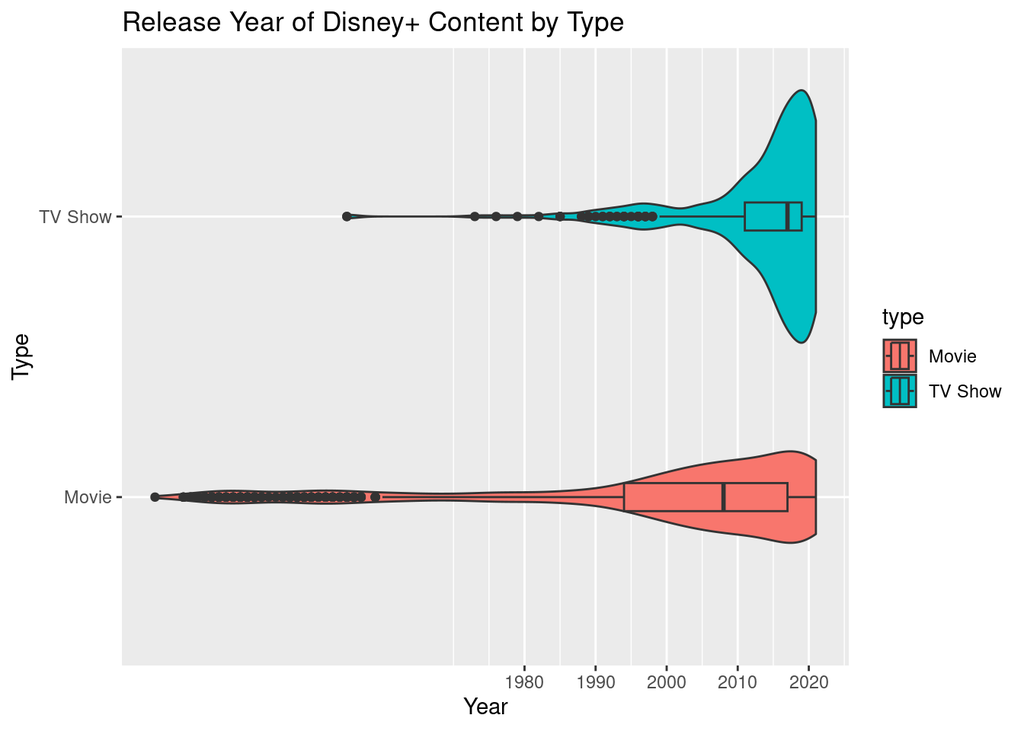

```r
library(ggplot2)
ggplot(Disney, aes(x = release_year, y = type, fill = type)) +
  geom_violin() +
  geom_boxplot(width = 0.1) +
  scale_x_continuous(breaks = seq(1980, 2020, 10)) +
  labs(title = "Release Year of Disney+ Content by Type",
       x = "Year",
       y = "Type")
```

### Visualization 2: Program Type

**This plot uses the Disney+ Dataset.**

Create a waffle plot (which you learned in DataCamp: [Visualization Best Practices in R](https://app.datacamp.com/learn/courses/visualization-best-practices-in-r)) to display the distribution of program `type` on Disney+.

- Give the plot the title “Streaming Content on Disney+”.
- Change the colors of the squares to something other than the defaults.
- Use an x-axis label to indicate roughly how many programs each square represents.

Hint: Use `round(100 * prop.table(table(DATASETNAME$VARIABLENAME)))` to create the “case_counts” data for the waffle plot. Swap out the capital letter placeholders in the instructions for the correct dataset name and variable name.

```r
library(waffle)
library(ggplot2)
Disney <- read_rds("data/disneypluscontent.rds")
glimpse(Disney)
```

```
Rows: 1,446
Columns: 13
$ show_id       <chr> "s1", "s2", "s3", "s4", "s6", "s7", "s8", "s9", "s10", "…
$ type          <chr> "Movie", "Movie", "Movie", "Movie", "Movie", "TV Show", …
$ title         <chr> "Duck the Halls: A Mickey Mouse Christmas Special", "Ern…
$ director      <chr> "Alonso Ramirez Ramos, Dave Wasson", "John Cherry", "Kar…
$ cast          <chr> "Chris Diamantopoulos, Tony Anselmo, Tress MacNeille, Bi…
$ country       <chr> NA, NA, "United States", NA, "United States", NA, "Unite…
$ date_added    <chr> "26-Nov-21", "26-Nov-21", "26-Nov-21", "26-Nov-21", "24-…
$ release_year  <dbl> 2016, 1988, 2011, 2021, 2021, 2021, 2015, 2019, 2008, 20…
$ rating        <fct> TV-G, PG, TV-G, TV-PG, PG-13, TV-14, TV-14, TV-PG, G, TV…
$ duration      <chr> "23", "91", "23", "41", "94", "1", "2", "2", "45", "59",…
$ duration_unit <chr> "min", "min", "min", "min", "min", "Seasons", "Seasons",…
$ listed_in     <chr> "Animation, Family", "Comedy", "Animation, Comedy, Famil…
$ description   <chr> "Join Mickey and the gang as they duck the halls!", "San…
```

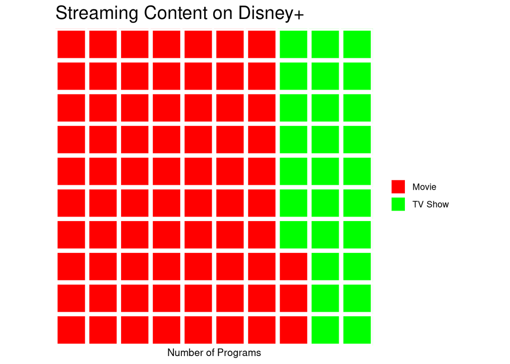

```r
case_counts <- round(100 * prop.table(table(Disney$type)))
waffle(case_counts, colors = c("#FF0000", "#00FF00", "#0000FF"), title = "Streaming Content on Disney+", xlab = "Number of Programs")
```

### Visualization 3: Choose a Plot!

**This plot uses the Disney+ Dataset.**

Create one other plot of your choice from the Disney+ Dataset to explore a question of interest. You are welcome to perform additional manipulations on the data, if needed. Add an appropriate title and axis labels, as well as any other necessary formatting.

```r
library(ggplot2)
Disney <- read_rds("data/disneypluscontent.rds")
glimpse(Disney)
```

```
Rows: 1,446
Columns: 13
$ show_id       <chr> "s1", "s2", "s3", "s4", "s6", "s7", "s8", "s9", "s10", "…
$ type          <chr> "Movie", "Movie", "Movie", "Movie", "Movie", "TV Show", …
$ title         <chr> "Duck the Halls: A Mickey Mouse Christmas Special", "Ern…
$ director      <chr> "Alonso Ramirez Ramos, Dave Wasson", "John Cherry", "Kar…
$ cast          <chr> "Chris Diamantopoulos, Tony Anselmo, Tress MacNeille, Bi…
$ country       <chr> NA, NA, "United States", NA, "United States", NA, "Unite…
$ date_added    <chr> "26-Nov-21", "26-Nov-21", "26-Nov-21", "26-Nov-21", "24-…
$ release_year  <dbl> 2016, 1988, 2011, 2021, 2021, 2021, 2015, 2019, 2008, 20…
$ rating        <fct> TV-G, PG, TV-G, TV-PG, PG-13, TV-14, TV-14, TV-PG, G, TV…
$ duration      <chr> "23", "91", "23", "41", "94", "1", "2", "2", "45", "59",…
$ duration_unit <chr> "min", "min", "min", "min", "min", "Seasons", "Seasons",…
$ listed_in     <chr> "Animation, Family", "Comedy", "Animation, Comedy, Famil…
$ description   <chr> "Join Mickey and the gang as they duck the halls!", "San…
```

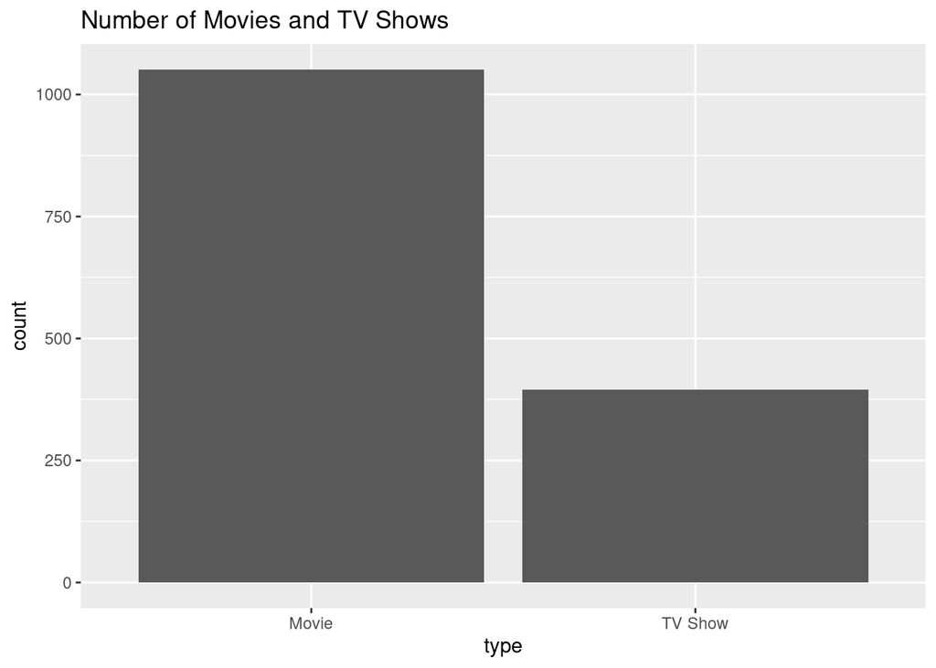

```r
show_counts = Disney %>%
  group_by(type) %>%
  summarize(count = n())
ggplot(show_counts, aes(x = type, y = count)) +
  geom_bar(stat = "identity")+
    ggtitle("Number of Movies and TV Shows")
```

### Visualization 4: Content Volume

**This plot uses the Streaming Dataset.**

Create a barplot to display how many shows are offered on each of the four streaming services. Choose appropriate colors, labels, themes, and/or and other types of formatting that you feel will enhance the meaning or visual appearance of the plot.

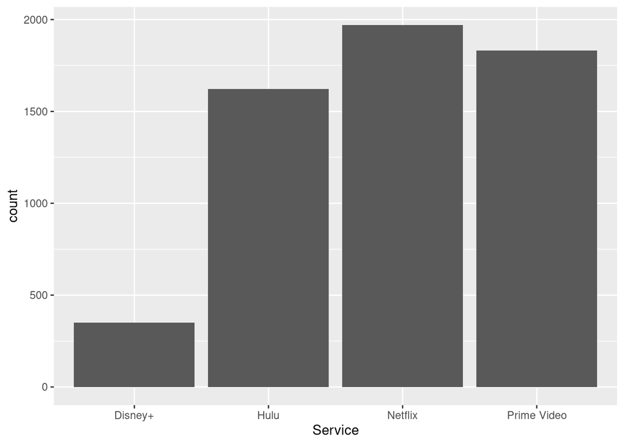

```r
shows_by_service <- Streamingcontent %>%
  group_by(Service) %>%
  summarize(count = n())
ggplot(shows_by_service, aes(x = Service, y = count)) +
  geom_bar(stat = "identity")
```

### Visualization 5: Choose a Plot!

**This plot uses the Streaming Dataset.**

Create one other plot of your choice from the Streaming Dataset to explore a question of interest. You are welcome to perform additional manipulations on the data, if needed. Add an appropriate title and axis labels, as well as any other necessary formatting.

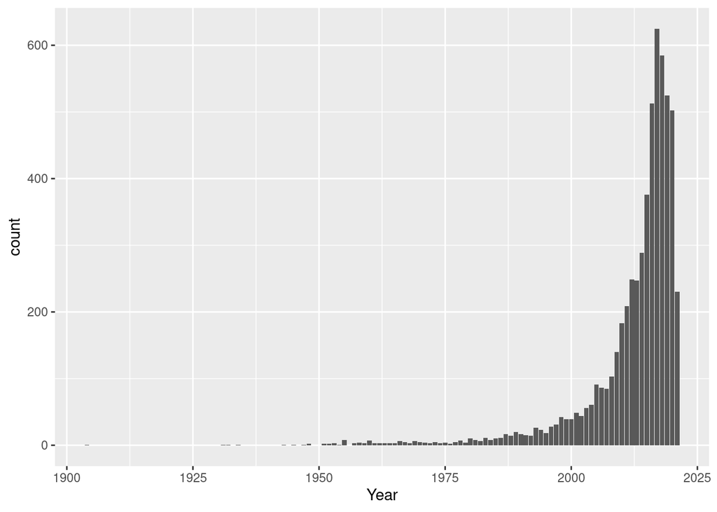

```r
shows_by_year <- Streamingcontent %>%
  group_by(Year) %>%
  summarize(count = n())
ggplot(shows_by_year, aes(x = Year, y = count)) +
  geom_bar(stat = "identity")
```

## Questions

**Question 1:** Based on your plots, make five informational statements or comparisons regarding the Disney+ streaming service.

**Question 2:** What other data would you like to have, or which existing variables would you like to see transformed, if you were going to do further explorations or visualizations? Give at least two examples.

**ANSWER**

Age group of people watching Disney+ and other demographic information like gender, where they are watching from, etc.

**Question 3:** Explain the rationale behind the choices you made with regard to plot type, formatting, and so on, when you created Visualizations 3 and 5. Walk me through your process. What motivated your decisions?

**ANSWER**

Bar plots are easy to look at and understand thoroughly with a basic plot so I chose that one, also using another basic plot allowed complex information to be placed in a plot that I could read, rather than a violin plot. ***